# Risk Factor Analysis

## Outcome Variable

**Outcome Variable:** y_rate_haz

## Predictor Variables

**Intervention Variable:** cleanck

**Adjustment Set:**

- arm
- sex
- W_mage
- meducyrs
- feducyrs
- hhwealth_quart
- W_nrooms
- W_nhh
- W_nchldlt5
- trth2o
- impfloor
- delta_meducyrs
- delta_feducyrs
- delta_hhwealth_quart
- delta_W_nrooms
- delta_W_nhh
- delta_W_nchldlt5
- delta_trth2o
- delta_impfloor

## Stratifying Variables

The analysis was stratified on these variable(s):

- agecat
- studyid
- country

## Data Summary

| agecat | studyid | country | cleanck | n_cell | n |
| --- | --- | --- | --- | --- | --- |
| 0-3 months | CMC-V-BCS-2002 | INDIA | 1 | 40 | 88 |
| 0-3 months | CMC-V-BCS-2002 | INDIA | 0 | 48 | 88 |
| 0-3 months | GMS-Nepal | NEPAL | 1 | 6 | 460 |
| 0-3 months | GMS-Nepal | NEPAL | 0 | 454 | 460 |
| 0-3 months | IRC | INDIA | 1 | 212 | 369 |
| 0-3 months | IRC | INDIA | 0 | 157 | 369 |
| 0-3 months | MAL-ED | PERU | 1 | 1 | 1 |
| 0-3 months | MAL-ED | PERU | 0 | 0 | 1 |
| 0-3 months | MAL-ED | SOUTH AFRICA | 1 | 1 | 2 |
| 0-3 months | MAL-ED | SOUTH AFRICA | 0 | 1 | 2 |
| 0-3 months | NIH-Crypto | BANGLADESH | 1 | 334 | 547 |
| 0-3 months | NIH-Crypto | BANGLADESH | 0 | 213 | 547 |
| 0-3 months | PROVIDE | BANGLADESH | 1 | 529 | 640 |
| 0-3 months | PROVIDE | BANGLADESH | 0 | 111 | 640 |
| 3-6 months | CMC-V-BCS-2002 | INDIA | 1 | 133 | 307 |
| 3-6 months | CMC-V-BCS-2002 | INDIA | 0 | 174 | 307 |
| 3-6 months | GMS-Nepal | NEPAL | 1 | 6 | 424 |
| 3-6 months | GMS-Nepal | NEPAL | 0 | 418 | 424 |
| 3-6 months | IRC | INDIA | 1 | 224 | 390 |
| 3-6 months | IRC | INDIA | 0 | 166 | 390 |
| 3-6 months | MAL-ED | SOUTH AFRICA | 1 | 1 | 1 |
| 3-6 months | MAL-ED | SOUTH AFRICA | 0 | 0 | 1 |
| 3-6 months | NIH-Crypto | BANGLADESH | 1 | 315 | 527 |
| 3-6 months | NIH-Crypto | BANGLADESH | 0 | 212 | 527 |
| 3-6 months | PROVIDE | BANGLADESH | 1 | 492 | 598 |
| 3-6 months | PROVIDE | BANGLADESH | 0 | 106 | 598 |
| 6-9 months | CMC-V-BCS-2002 | INDIA | 1 | 136 | 313 |
| 6-9 months | CMC-V-BCS-2002 | INDIA | 0 | 177 | 313 |
| 6-9 months | GMS-Nepal | NEPAL | 1 | 8 | 433 |
| 6-9 months | GMS-Nepal | NEPAL | 0 | 425 | 433 |

[output cut: 68 more lines]

The following strata were considered:

- agecat: 0-3 months, studyid: CMC-V-BCS-2002, country: INDIA
- agecat: 0-3 months, studyid: GMS-Nepal, country: NEPAL
- agecat: 0-3 months, studyid: IRC, country: INDIA
- agecat: 0-3 months, studyid: MAL-ED, country: PERU
- agecat: 0-3 months, studyid: MAL-ED, country: SOUTH AFRICA
- agecat: 0-3 months, studyid: NIH-Crypto, country: BANGLADESH
- agecat: 0-3 months, studyid: PROVIDE, country: BANGLADESH
- agecat: 12-15 months, studyid: CMC-V-BCS-2002, country: INDIA
- agecat: 12-15 months, studyid: GMS-Nepal, country: NEPAL
- agecat: 12-15 months, studyid: IRC, country: INDIA
- agecat: 12-15 months, studyid: MAL-ED, country: SOUTH AFRICA
- agecat: 12-15 months, studyid: NIH-Crypto, country: BANGLADESH
- agecat: 12-15 months, studyid: PROVIDE, country: BANGLADESH
- agecat: 15-18 months, studyid: CMC-V-BCS-2002, country: INDIA
- agecat: 15-18 months, studyid: GMS-Nepal, country: NEPAL
- agecat: 15-18 months, studyid: IRC, country: INDIA
- agecat: 15-18 months, studyid: MAL-ED, country: SOUTH AFRICA
- agecat: 15-18 months, studyid: NIH-Crypto, country: BANGLADESH
- agecat: 15-18 months, studyid: PROVIDE, country: BANGLADESH
- agecat: 18-21 months, studyid: CMC-V-BCS-2002, country: INDIA
- agecat: 18-21 months, studyid: GMS-Nepal, country: NEPAL
- agecat: 18-21 months, studyid: IRC, country: INDIA
- agecat: 18-21 months, studyid: MAL-ED, country: SOUTH AFRICA
- agecat: 18-21 months, studyid: NIH-Crypto, country: BANGLADESH
- agecat: 18-21 months, studyid: PROVIDE, country: BANGLADESH
- agecat: 21-24 months, studyid: CMC-V-BCS-2002, country: INDIA
- agecat: 21-24 months, studyid: GMS-Nepal, country: NEPAL
- agecat: 21-24 months, studyid: IRC, country: INDIA
- agecat: 21-24 months, studyid: MAL-ED, country: SOUTH AFRICA
- agecat: 21-24 months, studyid: NIH-Crypto, country: BANGLADESH
- agecat: 21-24 months, studyid: PROVIDE, country: BANGLADESH
- agecat: 3-6 months, studyid: CMC-V-BCS-2002, country: INDIA
- agecat: 3-6 months, studyid: GMS-Nepal, country: NEPAL
- agecat: 3-6 months, studyid: IRC, country: INDIA
- agecat: 3-6 months, studyid: MAL-ED, country: SOUTH AFRICA
- agecat: 3-6 months, studyid: NIH-Crypto, country: BANGLADESH
- agecat: 3-6 months, studyid: PROVIDE, country: BANGLADESH
- agecat: 6-9 months, studyid: CMC-V-BCS-2002, country: INDIA
- agecat: 6-9 months, studyid: GMS-Nepal, country: NEPAL
- agecat: 6-9 months, studyid: IRC, country: INDIA
- agecat: 6-9 months, studyid: MAL-ED, country: SOUTH AFRICA
- agecat: 6-9 months, studyid: NIH-Crypto, country: BANGLADESH
- agecat: 6-9 months, studyid: PROVIDE, country: BANGLADESH
- agecat: 9-12 months, studyid: CMC-V-BCS-2002, country: INDIA
- agecat: 9-12 months, studyid: GMS-Nepal, country: NEPAL
- agecat: 9-12 months, studyid: IRC, country: INDIA
- agecat: 9-12 months, studyid: MAL-ED, country: SOUTH AFRICA
- agecat: 9-12 months, studyid: NIH-Crypto, country: BANGLADESH
- agecat: 9-12 months, studyid: PROVIDE, country: BANGLADESH

### Dropped Strata

Some strata were dropped due to rare outcomes:

- agecat: 0-3 months, studyid: MAL-ED, country: PERU
- agecat: 0-3 months, studyid: MAL-ED, country: SOUTH AFRICA
- agecat: 3-6 months, studyid: MAL-ED, country: SOUTH AFRICA
- agecat: 6-9 months, studyid: MAL-ED, country: SOUTH AFRICA
- agecat: 9-12 months, studyid: MAL-ED, country: SOUTH AFRICA
- agecat: 12-15 months, studyid: MAL-ED, country: SOUTH AFRICA
- agecat: 15-18 months, studyid: MAL-ED, country: SOUTH AFRICA
- agecat: 18-21 months, studyid: MAL-ED, country: SOUTH AFRICA
- agecat: 21-24 months, studyid: GMS-Nepal, country: NEPAL
- agecat: 21-24 months, studyid: MAL-ED, country: SOUTH AFRICA

## Methods Detail

We’re interested in the causal parameters $E[Y_a]$ for all values of $a \in \mathcal{A}$. These parameters represent the mean outcome if, possibly contrary to fact, we intervened to set all units to have $A=a$. Under the randomization and positivity assumptions, these are identified by the statistical parameters $\psi_a=E_W[E_{Y|A,W}(Y|A=a,W)]$. In addition, we’re interested in the mean of $Y$, $E[Y]$ under no intervention (the observed mean). We will estimate these parameters by using SuperLearner to fit the relevant likelihood factors – $E_{Y|A,W}(Y|A=a,W)$ and $p(A=a|W)$, and then updating our likelihood fit using a joint TMLE.

For unadjusted analyses ($W=\{\}$), initial likelihoods were estimated using Lrnr_glm to estimate the simple $E(Y|A)$ and Lrnr_mean to estimate $p(A)$. For adjusted analyses, a small library containing Lrnr_glmnet, Lrnr_xgboost, and Lrnr_mean was used.

Having estimated these parameters, we will then use the delta method to estimate relative risks and attributable risks relative to a prespecified baseline level of $A$.

# Results Detail

## Results Plots

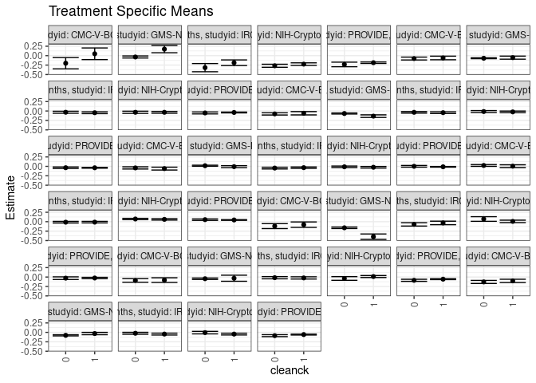

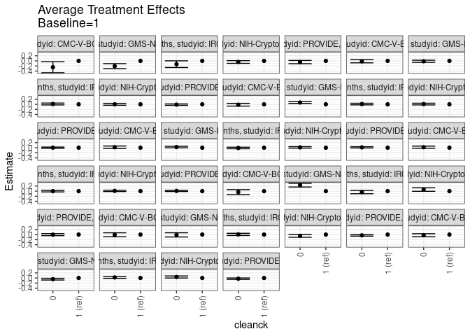

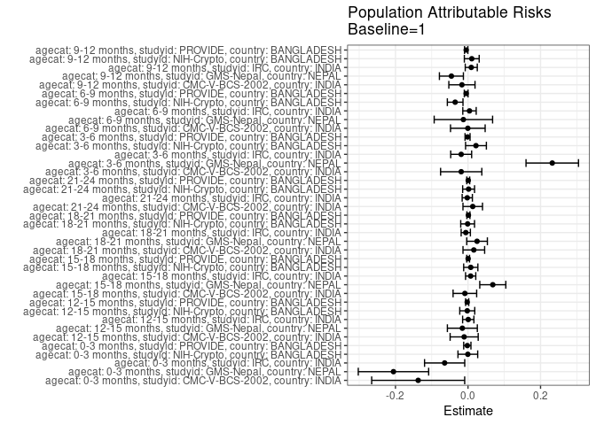

## Results Table

### Parameter: TSM

| agecat | studyid | country | intervention_level | baseline_level | estimate | ci_lower | ci_upper |
| --- | --- | --- | --- | --- | --- | --- | --- |
| 0-3 months | CMC-V-BCS-2002 | INDIA | 1 | NA | 0.0495151 | -0.1049134 | 0.2039436 |
| 0-3 months | CMC-V-BCS-2002 | INDIA | 0 | NA | -0.2004776 | -0.3497273 | -0.0512280 |
| 0-3 months | GMS-Nepal | NEPAL | 1 | NA | 0.1731986 | 0.0774761 | 0.2689210 |
| 0-3 months | GMS-Nepal | NEPAL | 0 | NA | -0.0350183 | -0.0621623 | -0.0078743 |
| 0-3 months | IRC | INDIA | 1 | NA | -0.1876195 | -0.2627530 | -0.1124861 |
| 0-3 months | IRC | INDIA | 0 | NA | -0.3173619 | -0.4255474 | -0.2091764 |
| 0-3 months | NIH-Crypto | BANGLADESH | 1 | NA | -0.2243928 | -0.2587076 | -0.1900780 |
| 0-3 months | NIH-Crypto | BANGLADESH | 0 | NA | -0.2681385 | -0.3082837 | -0.2279934 |
| 0-3 months | PROVIDE | BANGLADESH | 1 | NA | -0.1861491 | -0.2058816 | -0.1664167 |
| 0-3 months | PROVIDE | BANGLADESH | 0 | NA | -0.2331365 | -0.2935826 | -0.1726904 |
| 3-6 months | CMC-V-BCS-2002 | INDIA | 1 | NA | -0.0792278 | -0.1512519 | -0.0072037 |
| 3-6 months | CMC-V-BCS-2002 | INDIA | 0 | NA | -0.1172758 | -0.1823773 | -0.0521742 |
| 3-6 months | GMS-Nepal | NEPAL | 1 | NA | -0.3974205 | -0.4687983 | -0.3260427 |
| 3-6 months | GMS-Nepal | NEPAL | 0 | NA | -0.1617840 | -0.1819009 | -0.1416670 |
| 3-6 months | IRC | INDIA | 1 | NA | -0.0329602 | -0.0794751 | 0.0135547 |
| 3-6 months | IRC | INDIA | 0 | NA | -0.0713708 | -0.1159305 | -0.0268110 |
| 3-6 months | NIH-Crypto | BANGLADESH | 1 | NA | 0.0082879 | -0.0237003 | 0.0402760 |
| 3-6 months | NIH-Crypto | BANGLADESH | 0 | NA | 0.0712208 | 0.0096486 | 0.1327929 |
| 3-6 months | PROVIDE | BANGLADESH | 1 | NA | -0.0257030 | -0.0439216 | -0.0074843 |
| 3-6 months | PROVIDE | BANGLADESH | 0 | NA | -0.0294032 | -0.0638446 | 0.0050382 |
| 6-9 months | CMC-V-BCS-2002 | INDIA | 1 | NA | -0.0814929 | -0.1431395 | -0.0198464 |
| 6-9 months | CMC-V-BCS-2002 | INDIA | 0 | NA | -0.0904592 | -0.1378530 | -0.0430654 |
| 6-9 months | GMS-Nepal | NEPAL | 1 | NA | -0.0321023 | -0.1124147 | 0.0482102 |
| 6-9 months | GMS-Nepal | NEPAL | 0 | NA | -0.0450512 | -0.0643517 | -0.0257508 |
| 6-9 months | IRC | INDIA | 1 | NA | -0.0232665 | -0.0528250 | 0.0062921 |
| 6-9 months | IRC | INDIA | 0 | NA | -0.0175357 | -0.0474222 | 0.0123508 |
| 6-9 months | NIH-Crypto | BANGLADESH | 1 | NA | 0.0134751 | -0.0127121 | 0.0396622 |
| 6-9 months | NIH-Crypto | BANGLADESH | 0 | NA | -0.0379772 | -0.0864783 | 0.0105238 |
| 6-9 months | PROVIDE | BANGLADESH | 1 | NA | -0.0563494 | -0.0685016 | -0.0441972 |
| 6-9 months | PROVIDE | BANGLADESH | 0 | NA | -0.0868031 | -0.1143557 | -0.0592505 |
| 9-12 months | CMC-V-BCS-2002 | INDIA | 1 | NA | -0.1020634 | -0.1458439 | -0.0582829 |
| 9-12 months | CMC-V-BCS-2002 | INDIA | 0 | NA | -0.1301396 | -0.1706318 | -0.0896474 |
| 9-12 months | GMS-Nepal | NEPAL | 1 | NA | -0.0314007 | -0.0618148 | -0.0009866 |
| 9-12 months | GMS-Nepal | NEPAL | 0 | NA | -0.0780277 | -0.0930251 | -0.0630303 |
| 9-12 months | IRC | INDIA | 1 | NA | -0.0451073 | -0.0703997 | -0.0198150 |
| 9-12 months | IRC | INDIA | 0 | NA | -0.0242337 | -0.0487970 | 0.0003296 |
| 9-12 months | NIH-Crypto | BANGLADESH | 1 | NA | -0.0455896 | -0.0696010 | -0.0215782 |
| 9-12 months | NIH-Crypto | BANGLADESH | 0 | NA | -0.0066082 | -0.0394163 | 0.0262000 |
| 9-12 months | PROVIDE | BANGLADESH | 1 | NA | -0.0580013 | -0.0703231 | -0.0456795 |
| 9-12 months | PROVIDE | BANGLADESH | 0 | NA | -0.0866366 | -0.1129164 | -0.0603568 |
| 12-15 months | CMC-V-BCS-2002 | INDIA | 1 | NA | -0.0606295 | -0.1088377 | -0.0124212 |
| 12-15 months | CMC-V-BCS-2002 | INDIA | 0 | NA | -0.0764773 | -0.1144802 | -0.0384744 |
| 12-15 months | GMS-Nepal | NEPAL | 1 | NA | -0.0525575 | -0.0932027 | -0.0119122 |
| 12-15 months | GMS-Nepal | NEPAL | 0 | NA | -0.0684343 | -0.0802563 | -0.0566123 |
| 12-15 months | IRC | INDIA | 1 | NA | -0.0453368 | -0.0696393 | -0.0210344 |
| 12-15 months | IRC | INDIA | 0 | NA | -0.0333271 | -0.0599241 | -0.0067301 |
| 12-15 months | NIH-Crypto | BANGLADESH | 1 | NA | -0.0344931 | -0.0582579 | -0.0107282 |
| 12-15 months | NIH-Crypto | BANGLADESH | 0 | NA | -0.0342716 | -0.0630475 | -0.0054957 |
| 12-15 months | PROVIDE | BANGLADESH | 1 | NA | -0.0386614 | -0.0498864 | -0.0274364 |
| 12-15 months | PROVIDE | BANGLADESH | 0 | NA | -0.0511673 | -0.0770242 | -0.0253105 |
| 15-18 months | CMC-V-BCS-2002 | INDIA | 1 | NA | -0.0594510 | -0.1032434 | -0.0156587 |
| 15-18 months | CMC-V-BCS-2002 | INDIA | 0 | NA | -0.0767210 | -0.1061985 | -0.0472435 |
| 15-18 months | GMS-Nepal | NEPAL | 1 | NA | -0.1358700 | -0.1700189 | -0.1017211 |
| 15-18 months | GMS-Nepal | NEPAL | 0 | NA | -0.0662360 | -0.0800615 | -0.0524104 |
| 15-18 months | IRC | INDIA | 1 | NA | -0.0441186 | -0.0672297 | -0.0210075 |
| 15-18 months | IRC | INDIA | 0 | NA | -0.0348626 | -0.0553915 | -0.0143337 |
| 15-18 months | NIH-Crypto | BANGLADESH | 1 | NA | -0.0239235 | -0.0460219 | -0.0018250 |
| 15-18 months | NIH-Crypto | BANGLADESH | 0 | NA | -0.0145079 | -0.0402851 | 0.0112693 |
| 15-18 months | PROVIDE | BANGLADESH | 1 | NA | -0.0380052 | -0.0477060 | -0.0283045 |
| 15-18 months | PROVIDE | BANGLADESH | 0 | NA | -0.0364980 | -0.0570178 | -0.0159782 |
| 18-21 months | CMC-V-BCS-2002 | INDIA | 1 | NA | -0.0597920 | -0.0980842 | -0.0214997 |
| 18-21 months | CMC-V-BCS-2002 | INDIA | 0 | NA | -0.0414721 | -0.0703340 | -0.0126102 |
| 18-21 months | GMS-Nepal | NEPAL | 1 | NA | -0.0084094 | -0.0345648 | 0.0177460 |
| 18-21 months | GMS-Nepal | NEPAL | 0 | NA | 0.0169791 | 0.0040007 | 0.0299576 |
| 18-21 months | IRC | INDIA | 1 | NA | -0.0348344 | -0.0539049 | -0.0157639 |
| 18-21 months | IRC | INDIA | 0 | NA | -0.0457678 | -0.0686605 | -0.0228751 |
| 18-21 months | NIH-Crypto | BANGLADESH | 1 | NA | -0.0243709 | -0.0457935 | -0.0029483 |
| 18-21 months | NIH-Crypto | BANGLADESH | 0 | NA | -0.0121507 | -0.0323302 | 0.0080288 |
| 18-21 months | PROVIDE | BANGLADESH | 1 | NA | -0.0120547 | -0.0208907 | -0.0032187 |
| 18-21 months | PROVIDE | BANGLADESH | 0 | NA | 0.0008913 | -0.0216365 | 0.0234192 |
| 21-24 months | CMC-V-BCS-2002 | INDIA | 1 | NA | 0.0046586 | -0.0319781 | 0.0412952 |
| 21-24 months | CMC-V-BCS-2002 | INDIA | 0 | NA | 0.0239374 | 0.0002749 | 0.0475998 |
| 21-24 months | IRC | INDIA | 1 | NA | -0.0121643 | -0.0327677 | 0.0084392 |
| 21-24 months | IRC | INDIA | 0 | NA | -0.0133266 | -0.0346253 | 0.0079720 |
| 21-24 months | NIH-Crypto | BANGLADESH | 1 | NA | 0.0617337 | 0.0428988 | 0.0805685 |
| 21-24 months | NIH-Crypto | BANGLADESH | 0 | NA | 0.0713177 | 0.0542024 | 0.0884330 |
| 21-24 months | PROVIDE | BANGLADESH | 1 | NA | 0.0456077 | 0.0360363 | 0.0551791 |
| 21-24 months | PROVIDE | BANGLADESH | 0 | NA | 0.0539373 | 0.0341137 | 0.0737609 |

### Parameter: E(Y)

| agecat | studyid | country | intervention_level | baseline_level | estimate | ci_lower | ci_upper |
| --- | --- | --- | --- | --- | --- | --- | --- |
| 0-3 months | CMC-V-BCS-2002 | INDIA | NA | NA | -0.0878386 | -0.1937874 | 0.0181102 |
| 0-3 months | GMS-Nepal | NEPAL | NA | NA | -0.0323024 | -0.0589635 | -0.0056413 |
| 0-3 months | IRC | INDIA | NA | NA | -0.2520229 | -0.3078384 | -0.1962074 |
| 0-3 months | NIH-Crypto | BANGLADESH | NA | NA | -0.2248633 | -0.2444011 | -0.2053256 |
| 0-3 months | PROVIDE | BANGLADESH | NA | NA | -0.1880402 | -0.2054115 | -0.1706689 |
| 3-6 months | CMC-V-BCS-2002 | INDIA | NA | NA | -0.0979615 | -0.1455947 | -0.0503283 |
| 3-6 months | GMS-Nepal | NEPAL | NA | NA | -0.1651184 | -0.1849912 | -0.1452456 |
| 3-6 months | IRC | INDIA | NA | NA | -0.0517747 | -0.0822588 | -0.0212906 |
| 3-6 months | NIH-Crypto | BANGLADESH | NA | NA | 0.0302642 | 0.0105575 | 0.0499710 |
| 3-6 months | PROVIDE | BANGLADESH | NA | NA | -0.0269625 | -0.0428628 | -0.0110622 |
| 6-9 months | CMC-V-BCS-2002 | INDIA | NA | NA | -0.0819656 | -0.1161677 | -0.0477635 |
| 6-9 months | GMS-Nepal | NEPAL | NA | NA | -0.0448120 | -0.0637374 | -0.0258865 |
| 6-9 months | IRC | INDIA | NA | NA | -0.0191453 | -0.0403295 | 0.0020389 |
| 6-9 months | NIH-Crypto | BANGLADESH | NA | NA | -0.0219170 | -0.0369369 | -0.0068971 |
| 6-9 months | PROVIDE | BANGLADESH | NA | NA | -0.0614264 | -0.0722690 | -0.0505838 |
| 9-12 months | CMC-V-BCS-2002 | INDIA | NA | NA | -0.1188156 | -0.1473352 | -0.0902961 |
| 9-12 months | GMS-Nepal | NEPAL | NA | NA | -0.0771479 | -0.0918027 | -0.0624932 |
| 9-12 months | IRC | INDIA | NA | NA | -0.0361183 | -0.0532692 | -0.0189675 |
| 9-12 months | NIH-Crypto | BANGLADESH | NA | NA | -0.0352217 | -0.0477064 | -0.0227371 |
| 9-12 months | PROVIDE | BANGLADESH | NA | NA | -0.0630470 | -0.0740183 | -0.0520757 |
| 12-15 months | CMC-V-BCS-2002 | INDIA | NA | NA | -0.0712336 | -0.0991765 | -0.0432907 |
| 12-15 months | GMS-Nepal | NEPAL | NA | NA | -0.0681340 | -0.0797070 | -0.0565610 |
| 12-15 months | IRC | INDIA | NA | NA | -0.0446142 | -0.0616724 | -0.0275560 |
| 12-15 months | NIH-Crypto | BANGLADESH | NA | NA | -0.0365229 | -0.0475564 | -0.0254894 |
| 12-15 months | PROVIDE | BANGLADESH | NA | NA | -0.0409107 | -0.0510053 | -0.0308161 |
| 15-18 months | CMC-V-BCS-2002 | INDIA | NA | NA | -0.0680871 | -0.0915055 | -0.0446686 |
| 15-18 months | GMS-Nepal | NEPAL | NA | NA | -0.0675196 | -0.0810553 | -0.0539839 |
| 15-18 months | IRC | INDIA | NA | NA | -0.0367739 | -0.0516890 | -0.0218588 |
| 15-18 months | NIH-Crypto | BANGLADESH | NA | NA | -0.0162904 | -0.0258853 | -0.0066955 |
| 15-18 months | PROVIDE | BANGLADESH | NA | NA | -0.0376437 | -0.0463882 | -0.0288992 |
| 18-21 months | CMC-V-BCS-2002 | INDIA | NA | NA | -0.0437658 | -0.0661084 | -0.0214232 |
| 18-21 months | GMS-Nepal | NEPAL | NA | NA | 0.0165414 | 0.0038665 | 0.0292163 |
| 18-21 months | IRC | INDIA | NA | NA | -0.0410011 | -0.0544100 | -0.0275923 |
| 18-21 months | NIH-Crypto | BANGLADESH | NA | NA | -0.0253964 | -0.0344213 | -0.0163714 |
| 18-21 months | PROVIDE | BANGLADESH | NA | NA | -0.0109399 | -0.0190984 | -0.0027814 |
| 21-24 months | CMC-V-BCS-2002 | INDIA | NA | NA | 0.0177011 | -0.0032847 | 0.0386869 |
| 21-24 months | IRC | INDIA | NA | NA | -0.0141818 | -0.0280342 | -0.0003294 |
| 21-24 months | NIH-Crypto | BANGLADESH | NA | NA | 0.0634123 | 0.0544343 | 0.0723903 |
| 21-24 months | PROVIDE | BANGLADESH | NA | NA | 0.0462342 | 0.0375872 | 0.0548812 |

### Parameter: ATE

| agecat | studyid | country | intervention_level | baseline_level | estimate | ci_lower | ci_upper |
| --- | --- | --- | --- | --- | --- | --- | --- |
| 0-3 months | CMC-V-BCS-2002 | INDIA | 1 | 1 | 0.0000000 | 0.0000000 | 0.0000000 |
| 0-3 months | CMC-V-BCS-2002 | INDIA | 0 | 1 | -0.2499927 | -0.4671709 | -0.0328146 |
| 0-3 months | GMS-Nepal | NEPAL | 1 | 1 | 0.0000000 | 0.0000000 | 0.0000000 |
| 0-3 months | GMS-Nepal | NEPAL | 0 | 1 | -0.2082168 | -0.3077134 | -0.1087202 |
| 0-3 months | IRC | INDIA | 1 | 1 | 0.0000000 | 0.0000000 | 0.0000000 |
| 0-3 months | IRC | INDIA | 0 | 1 | -0.1297424 | -0.2618227 | 0.0023380 |
| 0-3 months | NIH-Crypto | BANGLADESH | 1 | 1 | 0.0000000 | 0.0000000 | 0.0000000 |
| 0-3 months | NIH-Crypto | BANGLADESH | 0 | 1 | -0.0437457 | -0.0968473 | 0.0093558 |
| 0-3 months | PROVIDE | BANGLADESH | 1 | 1 | 0.0000000 | 0.0000000 | 0.0000000 |
| 0-3 months | PROVIDE | BANGLADESH | 0 | 1 | -0.0469874 | -0.1108422 | 0.0168675 |
| 3-6 months | CMC-V-BCS-2002 | INDIA | 1 | 1 | 0.0000000 | 0.0000000 | 0.0000000 |
| 3-6 months | CMC-V-BCS-2002 | INDIA | 0 | 1 | -0.0380480 | -0.1352465 | 0.0591506 |
| 3-6 months | GMS-Nepal | NEPAL | 1 | 1 | 0.0000000 | 0.0000000 | 0.0000000 |
| 3-6 months | GMS-Nepal | NEPAL | 0 | 1 | 0.2356365 | 0.1614780 | 0.3097950 |
| 3-6 months | IRC | INDIA | 1 | 1 | 0.0000000 | 0.0000000 | 0.0000000 |
| 3-6 months | IRC | INDIA | 0 | 1 | -0.0384106 | -0.1028816 | 0.0260604 |
| 3-6 months | NIH-Crypto | BANGLADESH | 1 | 1 | 0.0000000 | 0.0000000 | 0.0000000 |
| 3-6 months | NIH-Crypto | BANGLADESH | 0 | 1 | 0.0629329 | -0.0065030 | 0.1323688 |
| 3-6 months | PROVIDE | BANGLADESH | 1 | 1 | 0.0000000 | 0.0000000 | 0.0000000 |
| 3-6 months | PROVIDE | BANGLADESH | 0 | 1 | -0.0037003 | -0.0427494 | 0.0353489 |
| 6-9 months | CMC-V-BCS-2002 | INDIA | 1 | 1 | 0.0000000 | 0.0000000 | 0.0000000 |
| 6-9 months | CMC-V-BCS-2002 | INDIA | 0 | 1 | -0.0089663 | -0.0866647 | 0.0687322 |
| 6-9 months | GMS-Nepal | NEPAL | 1 | 1 | 0.0000000 | 0.0000000 | 0.0000000 |
| 6-9 months | GMS-Nepal | NEPAL | 0 | 1 | -0.0129489 | -0.0955480 | 0.0696501 |
| 6-9 months | IRC | INDIA | 1 | 1 | 0.0000000 | 0.0000000 | 0.0000000 |
| 6-9 months | IRC | INDIA | 0 | 1 | 0.0057308 | -0.0364884 | 0.0479499 |
| 6-9 months | NIH-Crypto | BANGLADESH | 1 | 1 | 0.0000000 | 0.0000000 | 0.0000000 |
| 6-9 months | NIH-Crypto | BANGLADESH | 0 | 1 | -0.0514523 | -0.1068053 | 0.0039006 |
| 6-9 months | PROVIDE | BANGLADESH | 1 | 1 | 0.0000000 | 0.0000000 | 0.0000000 |
| 6-9 months | PROVIDE | BANGLADESH | 0 | 1 | -0.0304538 | -0.0606480 | -0.0002595 |
| 9-12 months | CMC-V-BCS-2002 | INDIA | 1 | 1 | 0.0000000 | 0.0000000 | 0.0000000 |
| 9-12 months | CMC-V-BCS-2002 | INDIA | 0 | 1 | -0.0280762 | -0.0879018 | 0.0317494 |
| 9-12 months | GMS-Nepal | NEPAL | 1 | 1 | 0.0000000 | 0.0000000 | 0.0000000 |
| 9-12 months | GMS-Nepal | NEPAL | 0 | 1 | -0.0466270 | -0.0805378 | -0.0127163 |
| 9-12 months | IRC | INDIA | 1 | 1 | 0.0000000 | 0.0000000 | 0.0000000 |
| 9-12 months | IRC | INDIA | 0 | 1 | 0.0208737 | -0.0145364 | 0.0562837 |
| 9-12 months | NIH-Crypto | BANGLADESH | 1 | 1 | 0.0000000 | 0.0000000 | 0.0000000 |
| 9-12 months | NIH-Crypto | BANGLADESH | 0 | 1 | 0.0389814 | -0.0015916 | 0.0795545 |
| 9-12 months | PROVIDE | BANGLADESH | 1 | 1 | 0.0000000 | 0.0000000 | 0.0000000 |
| 9-12 months | PROVIDE | BANGLADESH | 0 | 1 | -0.0286353 | -0.0576899 | 0.0004193 |
| 12-15 months | CMC-V-BCS-2002 | INDIA | 1 | 1 | 0.0000000 | 0.0000000 | 0.0000000 |
| 12-15 months | CMC-V-BCS-2002 | INDIA | 0 | 1 | -0.0158478 | -0.0773005 | 0.0456049 |
| 12-15 months | GMS-Nepal | NEPAL | 1 | 1 | 0.0000000 | 0.0000000 | 0.0000000 |
| 12-15 months | GMS-Nepal | NEPAL | 0 | 1 | -0.0158768 | -0.0582064 | 0.0264528 |
| 12-15 months | IRC | INDIA | 1 | 1 | 0.0000000 | 0.0000000 | 0.0000000 |
| 12-15 months | IRC | INDIA | 0 | 1 | 0.0120097 | -0.0240845 | 0.0481040 |
| 12-15 months | NIH-Crypto | BANGLADESH | 1 | 1 | 0.0000000 | 0.0000000 | 0.0000000 |
| 12-15 months | NIH-Crypto | BANGLADESH | 0 | 1 | 0.0002215 | -0.0373014 | 0.0377443 |
| 12-15 months | PROVIDE | BANGLADESH | 1 | 1 | 0.0000000 | 0.0000000 | 0.0000000 |
| 12-15 months | PROVIDE | BANGLADESH | 0 | 1 | -0.0125060 | -0.0406998 | 0.0156879 |
| 15-18 months | CMC-V-BCS-2002 | INDIA | 1 | 1 | 0.0000000 | 0.0000000 | 0.0000000 |
| 15-18 months | CMC-V-BCS-2002 | INDIA | 0 | 1 | -0.0172699 | -0.0710416 | 0.0365018 |
| 15-18 months | GMS-Nepal | NEPAL | 1 | 1 | 0.0000000 | 0.0000000 | 0.0000000 |
| 15-18 months | GMS-Nepal | NEPAL | 0 | 1 | 0.0696340 | 0.0327926 | 0.1064755 |
| 15-18 months | IRC | INDIA | 1 | 1 | 0.0000000 | 0.0000000 | 0.0000000 |
| 15-18 months | IRC | INDIA | 0 | 1 | 0.0092560 | -0.0222006 | 0.0407127 |
| 15-18 months | NIH-Crypto | BANGLADESH | 1 | 1 | 0.0000000 | 0.0000000 | 0.0000000 |
| 15-18 months | NIH-Crypto | BANGLADESH | 0 | 1 | 0.0094156 | -0.0245575 | 0.0433887 |
| 15-18 months | PROVIDE | BANGLADESH | 1 | 1 | 0.0000000 | 0.0000000 | 0.0000000 |
| 15-18 months | PROVIDE | BANGLADESH | 0 | 1 | 0.0015072 | -0.0212077 | 0.0242222 |
| 18-21 months | CMC-V-BCS-2002 | INDIA | 1 | 1 | 0.0000000 | 0.0000000 | 0.0000000 |
| 18-21 months | CMC-V-BCS-2002 | INDIA | 0 | 1 | 0.0183199 | -0.0297613 | 0.0664011 |
| 18-21 months | GMS-Nepal | NEPAL | 1 | 1 | 0.0000000 | 0.0000000 | 0.0000000 |
| 18-21 months | GMS-Nepal | NEPAL | 0 | 1 | 0.0253885 | -0.0038098 | 0.0545869 |
| 18-21 months | IRC | INDIA | 1 | 1 | 0.0000000 | 0.0000000 | 0.0000000 |
| 18-21 months | IRC | INDIA | 0 | 1 | -0.0109334 | -0.0413099 | 0.0194431 |
| 18-21 months | NIH-Crypto | BANGLADESH | 1 | 1 | 0.0000000 | 0.0000000 | 0.0000000 |
| 18-21 months | NIH-Crypto | BANGLADESH | 0 | 1 | 0.0122203 | -0.0172499 | 0.0416904 |
| 18-21 months | PROVIDE | BANGLADESH | 1 | 1 | 0.0000000 | 0.0000000 | 0.0000000 |
| 18-21 months | PROVIDE | BANGLADESH | 0 | 1 | 0.0129460 | -0.0112690 | 0.0371611 |
| 21-24 months | CMC-V-BCS-2002 | INDIA | 1 | 1 | 0.0000000 | 0.0000000 | 0.0000000 |
| 21-24 months | CMC-V-BCS-2002 | INDIA | 0 | 1 | 0.0192788 | -0.0244709 | 0.0630285 |
| 21-24 months | IRC | INDIA | 1 | 1 | 0.0000000 | 0.0000000 | 0.0000000 |
| 21-24 months | IRC | INDIA | 0 | 1 | -0.0011624 | -0.0308356 | 0.0285108 |
| 21-24 months | NIH-Crypto | BANGLADESH | 1 | 1 | 0.0000000 | 0.0000000 | 0.0000000 |
| 21-24 months | NIH-Crypto | BANGLADESH | 0 | 1 | 0.0095840 | -0.0159325 | 0.0351006 |
| 21-24 months | PROVIDE | BANGLADESH | 1 | 1 | 0.0000000 | 0.0000000 | 0.0000000 |
| 21-24 months | PROVIDE | BANGLADESH | 0 | 1 | 0.0083296 | -0.0136442 | 0.0303034 |

### Parameter: PAR

| agecat | studyid | country | intervention_level | baseline_level | estimate | ci_lower | ci_upper |
| --- | --- | --- | --- | --- | --- | --- | --- |
| 0-3 months | CMC-V-BCS-2002 | INDIA | 1 | NA | -0.1373537 | -0.2655557 | -0.0091517 |
| 0-3 months | GMS-Nepal | NEPAL | 1 | NA | -0.2055009 | -0.3025342 | -0.1084677 |
| 0-3 months | IRC | INDIA | 1 | NA | -0.0644034 | -0.1198011 | -0.0090056 |
| 0-3 months | NIH-Crypto | BANGLADESH | 1 | NA | -0.0004705 | -0.0276662 | 0.0267252 |
| 0-3 months | PROVIDE | BANGLADESH | 1 | NA | -0.0018911 | -0.0118867 | 0.0081045 |
| 3-6 months | CMC-V-BCS-2002 | INDIA | 1 | NA | -0.0187337 | -0.0755824 | 0.0381150 |
| 3-6 months | GMS-Nepal | NEPAL | 1 | NA | 0.2323021 | 0.1599489 | 0.3046552 |
| 3-6 months | IRC | INDIA | 1 | NA | -0.0188145 | -0.0476548 | 0.0100257 |
| 3-6 months | NIH-Crypto | BANGLADESH | 1 | NA | 0.0219764 | -0.0067017 | 0.0506545 |
| 3-6 months | PROVIDE | BANGLADESH | 1 | NA | -0.0012595 | -0.0081660 | 0.0056470 |
| 6-9 months | CMC-V-BCS-2002 | INDIA | 1 | NA | -0.0004727 | -0.0482121 | 0.0472668 |
| 6-9 months | GMS-Nepal | NEPAL | 1 | NA | -0.0127097 | -0.0932439 | 0.0678245 |
| 6-9 months | IRC | INDIA | 1 | NA | 0.0041212 | -0.0143599 | 0.0226022 |
| 6-9 months | NIH-Crypto | BANGLADESH | 1 | NA | -0.0353921 | -0.0569606 | -0.0138236 |
| 6-9 months | PROVIDE | BANGLADESH | 1 | NA | -0.0050770 | -0.0102290 | 0.0000750 |
| 9-12 months | CMC-V-BCS-2002 | INDIA | 1 | NA | -0.0167522 | -0.0528471 | 0.0193427 |
| 9-12 months | GMS-Nepal | NEPAL | 1 | NA | -0.0457472 | -0.0788158 | -0.0126787 |
| 9-12 months | IRC | INDIA | 1 | NA | 0.0089890 | -0.0075829 | 0.0255609 |
| 9-12 months | NIH-Crypto | BANGLADESH | 1 | NA | 0.0103679 | -0.0100896 | 0.0308253 |
| 9-12 months | PROVIDE | BANGLADESH | 1 | NA | -0.0050457 | -0.0097187 | -0.0003728 |
| 12-15 months | CMC-V-BCS-2002 | INDIA | 1 | NA | -0.0106041 | -0.0492982 | 0.0280900 |
| 12-15 months | GMS-Nepal | NEPAL | 1 | NA | -0.0155766 | -0.0568484 | 0.0256953 |
| 12-15 months | IRC | INDIA | 1 | NA | 0.0007226 | -0.0148239 | 0.0162692 |
| 12-15 months | NIH-Crypto | BANGLADESH | 1 | NA | -0.0020299 | -0.0226931 | 0.0186333 |
| 12-15 months | PROVIDE | BANGLADESH | 1 | NA | -0.0022493 | -0.0066222 | 0.0021235 |
| 15-18 months | CMC-V-BCS-2002 | INDIA | 1 | NA | -0.0086360 | -0.0411454 | 0.0238733 |
| 15-18 months | GMS-Nepal | NEPAL | 1 | NA | 0.0683504 | 0.0324192 | 0.1042817 |
| 15-18 months | IRC | INDIA | 1 | NA | 0.0073447 | -0.0067418 | 0.0214312 |
| 15-18 months | NIH-Crypto | BANGLADESH | 1 | NA | 0.0076331 | -0.0119310 | 0.0271971 |
| 15-18 months | PROVIDE | BANGLADESH | 1 | NA | 0.0003615 | -0.0035470 | 0.0042700 |
| 18-21 months | CMC-V-BCS-2002 | INDIA | 1 | NA | 0.0160262 | -0.0138150 | 0.0458674 |
| 18-21 months | GMS-Nepal | NEPAL | 1 | NA | 0.0249508 | -0.0035194 | 0.0534210 |
| 18-21 months | IRC | INDIA | 1 | NA | -0.0061667 | -0.0188788 | 0.0065453 |
| 18-21 months | NIH-Crypto | BANGLADESH | 1 | NA | -0.0010254 | -0.0200378 | 0.0179870 |
| 18-21 months | PROVIDE | BANGLADESH | 1 | NA | 0.0011148 | -0.0031326 | 0.0053623 |
| 21-24 months | CMC-V-BCS-2002 | INDIA | 1 | NA | 0.0130425 | -0.0138851 | 0.0399702 |
| 21-24 months | IRC | INDIA | 1 | NA | -0.0020176 | -0.0161077 | 0.0120726 |
| 21-24 months | NIH-Crypto | BANGLADESH | 1 | NA | 0.0016786 | -0.0147132 | 0.0180704 |
| 21-24 months | PROVIDE | BANGLADESH | 1 | NA | 0.0006265 | -0.0034328 | 0.0046859 |